# Sample Size Estimation while Controlling Covariates Using the R Package icensmis

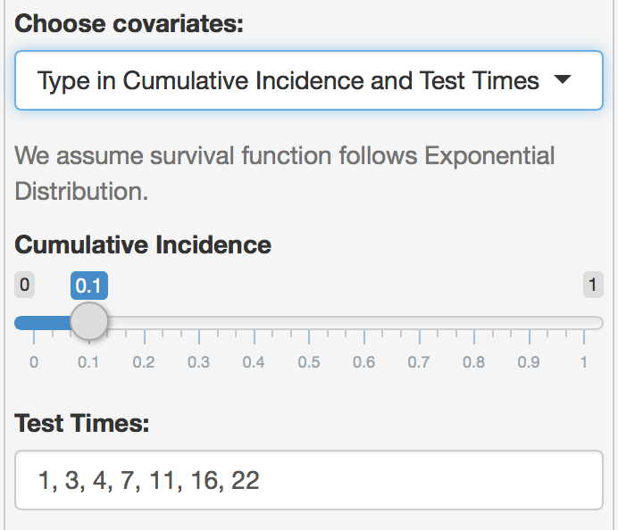

7. Move the slider to set a value for Rho. Default value is 0.5, which indicates equally allocation between two groups.

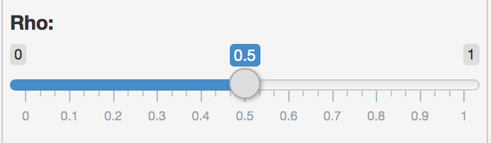

8. Input value for Pmiss. Remember it is a probability, the value should between 0 and 1.  
If the missing probability is not same at each test time, then you could type in several values with a comma as seperator, and keep the length same as testtime. If only type in one value, then you assume an indentical probability of missingness.

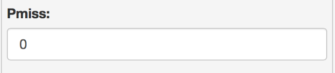

9. Input value for Pcensor. Remember it is a probability, the value should between 0 and 1.  
If the censoring probability is not same at each test time, then you could type in several values with a comma as seperator, and keep the length same as testtime. If only type in one value, then you assume an indentical probability of censoring.

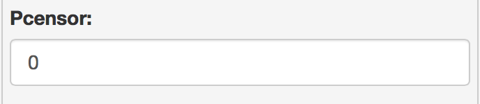

10. Choose a study design you want to investigate.

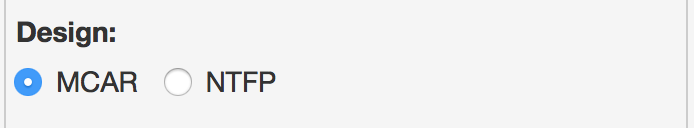

11. Input a value for Negpred. Remember it is a probability, the value should between 0 and 1.

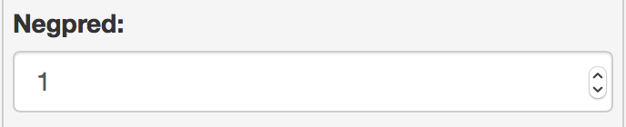

12. After finishing all the settings, you click “Analysis” button to review the results in the right column.

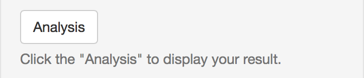

13. If you want to save all your settings and results into a csv. file for further study, you could name you dataset and click “Download” to keep it in your local address.

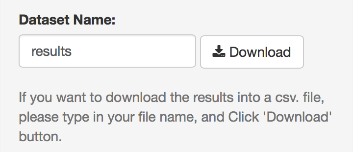

#### 3.2 Power Calculation

Steps

1. Choose “Power” as your subject.

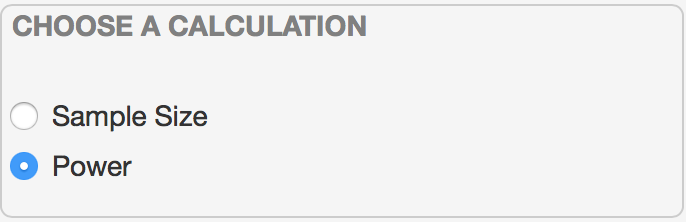

2. Input value of sample size. If you want to test different sample size, use a comma between each one.

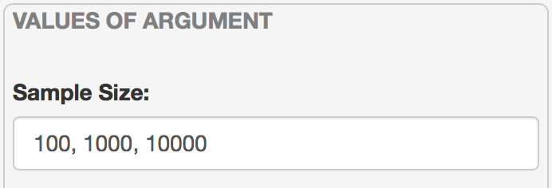

Repeat the following steps same as in the **3.1 Sample Size Calculation** part from Step 3 to 13.